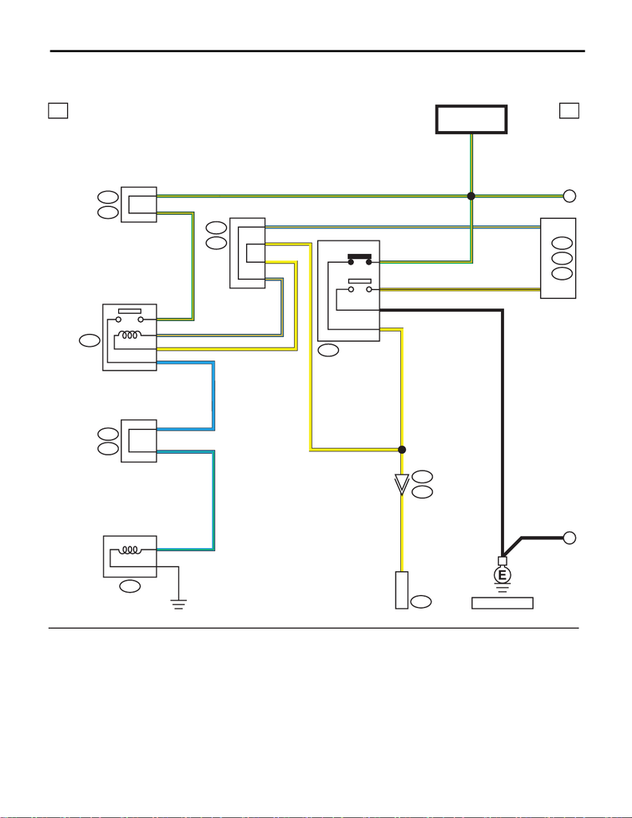

WI-79

Air Conditioning System

WIRING SYSTEM

7. Air Conditioning System

A: WIRING DIAGRAM

B135

B134

B136

D: B361

A: F108

F27

WI-44289

15

B:

A:

C:

F24

i88

B10

C: B360

B: F109

a a

2

1

i238

B584

G/O

G/O

G/O

G/O

A:

C:

F37

F35

A

B

B

Y

Y

Y

2

B

Y/B

3

1 G/O

22

Y

Y

L

24

21

L/O

L

L/O23

M/B

L/G

L/G

1

A4

C3

B

11

D14 L/O

A9

D13

A11

C1

B9

L/O

Y/B

2

1

4

Y

Y

ECM

MAGNET CLUTCH

THROUGH JOINT

CONNECTOR

THROUGH JOINT

CONNECTOR

A/C CONTROL

PANEL

PRESSURE

SWITCH

FB-46

F/B FUSE NO. 22

(IG)

: ENGINE TYPE FA : A1

ENGINE TYPE EJ : B35

: ENGINE TYPE FA : A7

ENGINE TYPE EJ : C7

A/C RELAY

REF. TO GND [b]

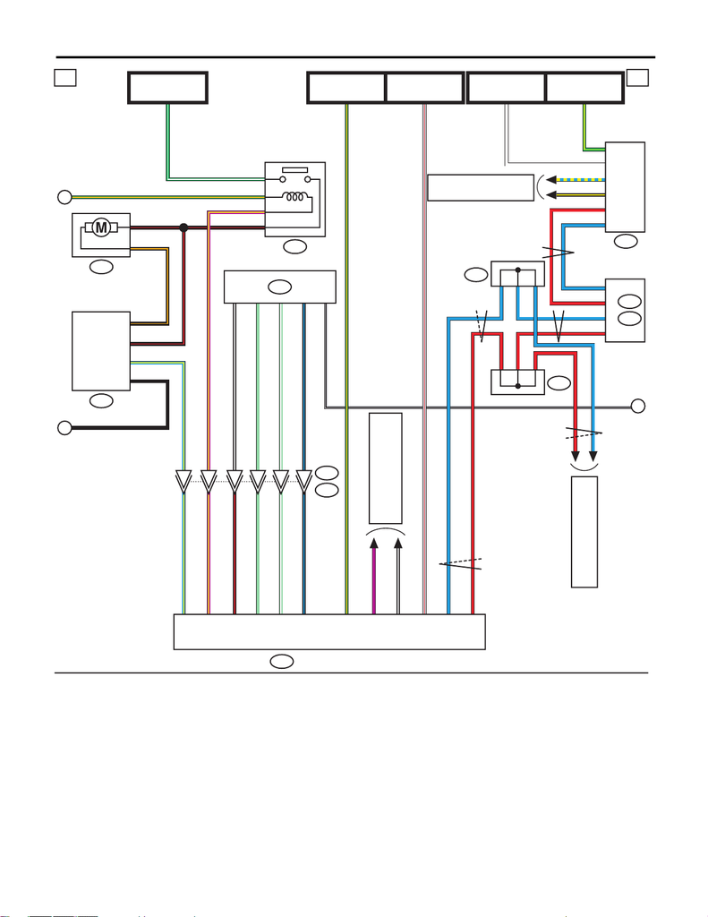

WI-80

Air Conditioning System

WIRING SYSTEM

WI-44290

14

5

12

11

3

4

B163

B87

B57

A

i88

B

b b

i238

B584

1

GR/R

G/O

G/Y

W

G/W

15

GR/R

32 G/O

B/W

35

V

2

2

2

2

2

2

37

R

20

L

19

L/Y

8

6

12

10

9

40

C

1

2

6

5

4

3

4

4

2

2

G/O

GR/B

16W

8

5

4B/Y

6R

14L

GR/B

G/W

G/O

V/Y

B/R

1

B/O

B/O

1

B/R

L/Y

1B

B/R

2

B386

V/Y

3

B

L/Y

L/Y

V/Y

V/Y

B/R

LG

LG

B/W

LG/W

LG/W

B/L

B/R

LG

LG/W

B/L

B/L

LG

B/W

LG/W

B/L

B40

DATA LINK

CONNECTOR

B281

i84

B:

C:

BODY

INTEGRATED

UNIT

B28L

B20R

C35L

C27R

L

R

1

i232

i233

2

BLOWER MOTOR RELAY

POWER TRANSISTOR

BLOWER MOTOR

FB-8

F/B FUSE NO. 27 (B)

F/B FUSE NO. 28 (B)

FB-45

F/B FUSE NO. 22

(IG)

FB-28

F/B FUSE NO. 31

(ACC)

MB-27

M/B FUSE NO. 13

(B)

FB-32

F/B FUSE NO. 4

(IG)

REF. TO CLEARANCE LIGHT &

ILLUMINATION LIGHT SYSTEM

[1d] [2d]

INTAKE DOOR ACTUATOR

: ENGINE TYPE FA : B/R

ENGINE TYPE EJ : B/W

A/C CONTROL PANEL

REF. TO ENGINE ELECTRICAL

SYSTEM [1g] [2g] [3f] [4f]

REF. TO CAN COMMUNICATION

SYSTEM [b]

J/C

J/C

: TERMINAL No. OPTIONAL ARRANGEMENT

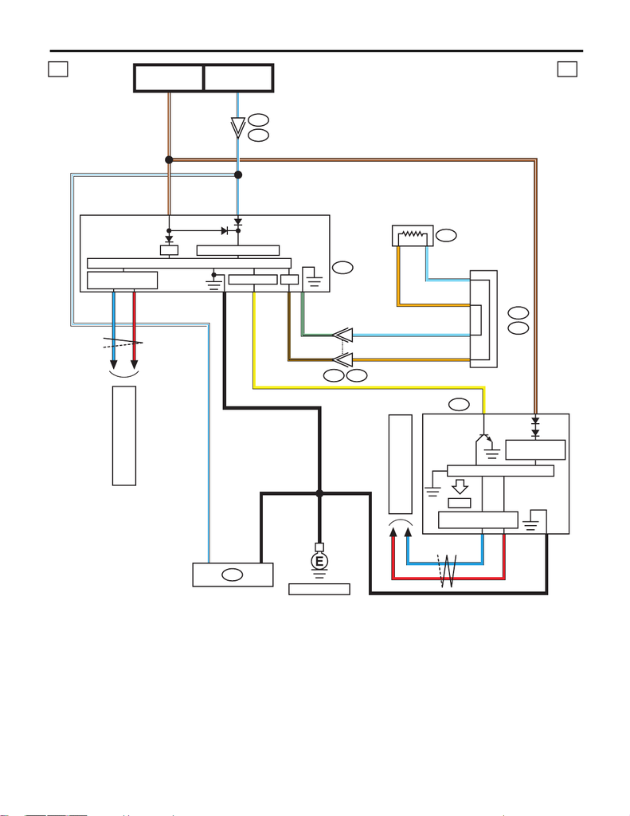

WI-81

Air Conditioning System

WIRING SYSTEM

WI-44291

3

i88

i10

i238 B584

1

A:

F108

A:

i122

2

c c

i229

B551

BR/W

W/L

BR/W

32

20

40

36

L

33R

38B

28Y

27O/B

LG/B

I/F

I/F

A3

BR/W

A9

Y

A2B

A5L

A6R

LCD

W/L

31 W/L

34

B

B

MFD

SB

O

SBLG/B

OO/B

O

SB

O

SB

F78

1

2

A13

D11

A14

D10

D:

B361

W/L

THROUGH JOINT

CONNECTOR

AMBIENT SENSOR

FB-18

F/B FUSE NO. 7

(B)

FB-12

F/B FUSE NO. 2

(IG)

CAN TRANSCEIVER &

RECEIVER

MICRO COMPUTER

CONSTANT

VOLTAGE CIRCUIT

CAN TRANSCEIVER &

RECEIVER

MICRO COMPUTER

POWER SUPPLY CIRCUIT

COMBINATION

METER

A/C CONTROL PANEL

DRIVE CIRCUIT

REF. TO GND [e]

REF. TO CAN COMMUNICATION

SYSTEM [b]

REF. TO CAN COMMUNICATION

SYSTEM [b]

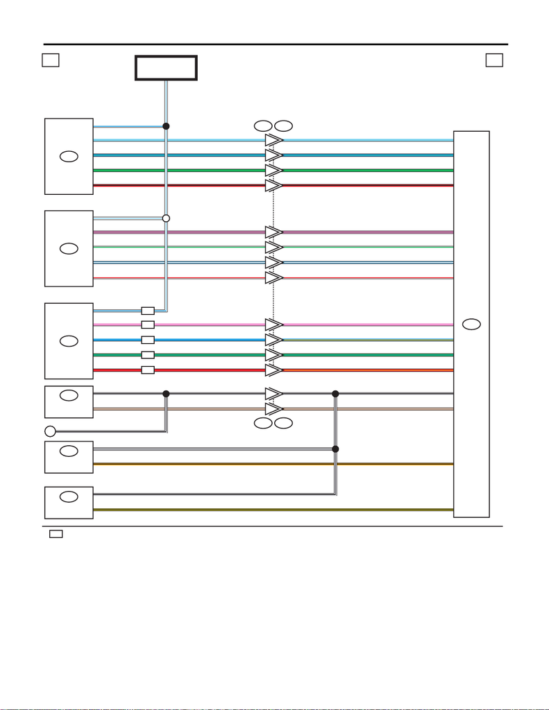

WI-82

Air Conditioning System

WIRING SYSTEM

WI-44292

B88

8

10

3

9

1

7

6

2

4

12

11

5

13

10

i55

i51

d d

1

B239

B77

B235

i88

B583 i237

B584 i238

28SB

27L/G

26G

25R/B

W/L3

SB1

L/G2

G5

R/B6

W/L

GG

L/G L/G

R/B R/B

SB SB

4P/B

3W/G

2L/W

1W/R

W/L3

P/B1

W/G2

L/W5

W/R6

W/L3

L/W L/W

W/G W/G

W/R W/R

P/B P/B

24P

23L/O

22G/L

21R/Y

P1

L2

G/L5

R6

G/L G/L

L L/O

R R/Y

14GR/B

18BR/W

GR/B1

BR/W2

GR/B GR/B

BR/W BR/W

17O/BO/B2

GR/B1

16Y/B

GR/B1

Y/B2

PP

GR/B

C

TE

TE

TE

TE

TE

TE

AIR MIX DOOR

ACTUATOR LH

MODE DOOR

ACTUATOR

FB-18

F/B FUSE NO. 7

(B)

A/C CONTROL PANEL

SUNLOAD

SENSOR

IN-VEHICLE

SENSOR

EVAPORATOR

SENSOR

1

: WITHOUT L/R INDEPENDENT AIR CONDITIONER : AIR MIX DOOR ACTUATOR

WITH L/R INDEPENDENT AIR CONDITIONER : AIR MIX DOOR ACTUATOR RH

: WITH L/R INDEPENDENT AIR CONDITIONER

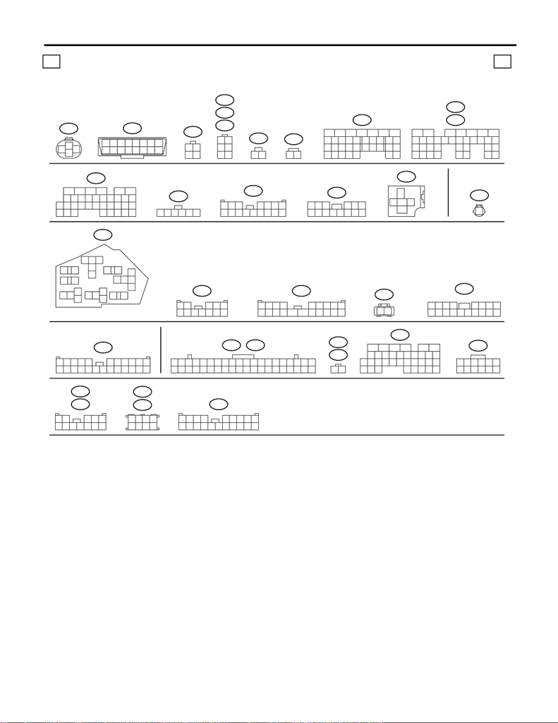

WI-83

Air Conditioning System

WIRING SYSTEM

WI-44293

e e

F24

i55

i51

F108

(GR)

A:

i10 i88

B40

(B)

1

9

8

16

2

10

7

15

3

11

6

14

4

12

5

13

B57

12

34

B239

B235

B77

12

34

56

B87

21

(BR)

B88

12

B134

18

23

26

24

25

98

15

1413121110

17

16

1234567

(B)

B281B:

B135B:

C:

B163

(GR)

B360

D:

(GR)

B361

29

10 11 12 13 14 15

2524

16

30

98

17 18 19

20

28

21 22 23

3231

26 27

33 34 35

123456

123 4567

89

10 11 12 13 14 15 16

123 456

789

10 11 12 13 14

B386

2

1

4

3

1

F27

24

23

25

12 13 14

15

16

26

2221

20

19

1817

10 11

2

4

5

13

7698

12

3

45

6789

10 11 12

F35

(L)

(B)

C:

F78

(B)

F37A:

1234

56789

10 11 12 13 14 15 16 17 18 19 20

21

1

9

23 8

10

4

11 12 13 14 15 16

567

17 18

F109B:

3412 89

10 11

12 13 14 15 16 17 18 19 20 21 22 23 24

567

11 12

9

10

2

15 1613 14 19

18

20

21 22 23 24 26

25

27 28 29 30 31 32 33 34 35 36 37 38 39 40

17

21

11 12

9

10

78

65341

2

i122

i237

i229

i238

(B)

A:

B136C:

12 345

6789

10 11 12

89

19 20

1234 567

10 11 12 13 14 15 16 17 18

19

18

21

20

2322 24 25 26

17

1

23

4

56

27

28 29 30

31 32 33 34 35

798

i84C:

i233

i232

78

5

6

34

21

A:

B10

2

3

1

4

(GR)

19

18

21

20

2322 24 25 26

17

1

23

4

56

27

28 29 30

31 32 33 34 35

798

151413121110 16

RELAY HOLDER

LIST OF CONNECTORS